# Project 2: Data Mining, Classification, Prediction

SDS322E

# Mining, Classification, Prediction

Cameron Dang crd2724

### Introduction

```r
library(tidyverse)
# reading in raw data
data_raw <- read_csv("~/Documents/Fall 2021/SDS322E/project2/openpowerlifting.csv")

# modifying data for project
data = data_raw %>%
    filter(Equipment == "Raw") %>%
    select(Name, Sex, Age, Date, BodyweightKg, Best3SquatKg,
        Best3BenchKg, Best3DeadliftKg, TotalKg, Wilks) %>%
    na.omit()

# dichotimization of Sex variable
binary = data$Sex %>%
    str_replace("M", "1") %>%
    str_replace("F", "0") %>%
    as.numeric()
data = data %>%
    mutate(Sex = binary)

# observations total data %>% dim()

# reducing number of observations
set.seed(123)
data <- data[sample(1:nrow(data), 10000), ]

# checking observations per binary group data %>%
# group_by(Sex) %>% summarize(n=n())
```

Update: The original csv file was around 240 megabytes, so it could not be pushed to github. I also ran into issues pushing a compressed version of the file. Please download it from https://www.kaggle.com/open-powerlifting/powerlifting-database if needed.

### Cluster Analysis

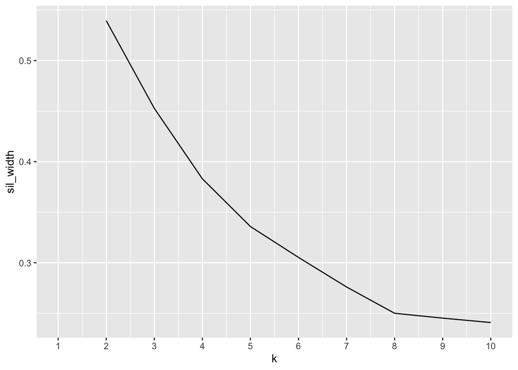

```r
library(cluster)
# defining clust_dat
clust_dat = data %>%
    select(BodyweightKg, Best3SquatKg, Best3DeadliftKg, Best3BenchKg)

# computing silhouette widths
sil_width <- vector()  #empty vector to hold mean sil width
for (i in 2:10) {
    kms <- kmeans(clust_dat, centers = i)  #compute k-means solution for each k
    sil <- silhouette(kms$cluster, dist(clust_dat))  #get sil widths
    sil_width[i] <- mean(sil[, 3])  #take averages (higher is better)
}
ggplot() + geom_line(aes(x = 1:10, y = sil_width)) + scale_x_continuous(name = "k",
    breaks = 1:10)
```

```r
# PAM
set.seed(123)
pam1 <- clust_dat %>%
    pam(k = 2)
pam1
```

```
## Medoids:
##        ID BodyweightKg Best3SquatKg Best3DeadliftKg Best3BenchKg
## [1,] 6986        89.85          200           230.0          135
## [2,] 6712        64.60          110           137.5           65
## Clustering vector:
##   [1] 1 2 2 1 1 1 1 1 1 1 1 2 1 2 2 2 2 1 2 1 1 2 1 2 2 1 1 2 1 2 2 2 1 2 2 1 1
##  [38] 1 1 1 1 1 1 2 1 2 1 2 1 1 2 1 2 1 2 1 2 2 1 2 1 1 2 2 1 1 1 1 1 1 1 1 1 2
##  [75] 2 1 1 1 2 2 1 2 1 2 2 1 2 1 1 1 1 1 1 1 1 1 2 2 2 1
##  [ reached getOption("max.print") -- omitted 9900 entries ]
## Objective function:
##    build     swap
## 59.93823 49.32349
##
## Available components:
##  [1] "medoids"    "id.med"     "clustering" "objective"  "isolation"
##  [6] "clusinfo"   "silinfo"    "diss"       "call"       "data"
```

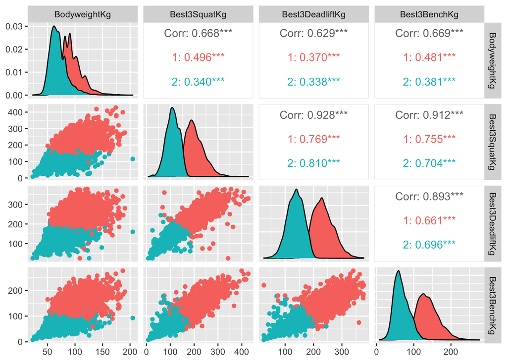

```r
# visualize
cluster = as.factor(pam1$clustering)
library(GGally)
ggpairs(clust_dat, aes(color = cluster))
```

```r
# goodness-of-fit
pam1$silinfo$avg.width
```

```
## [1] 0.540263
```

```r
# how well did it classify by Sex?  changing back to M/F so
# less confusing
factor = data$Sex %>%
    str_replace("1", "M") %>%
    str_replace("0", "F")
data %>%
    mutate(Sex = factor) %>%
    mutate(cluster = cluster) %>%
    select(cluster, Sex) %>%
    group_by(cluster, Sex) %>%
    summarize(n = n()) %>%
    mutate(prop = n/sum(n, na.rm = T)) %>%
    pivot_wider(-n, names_from = Sex, values_from = prop)
```

```
## # A tibble: 2 × 3
## # Groups:   cluster [2]
##   cluster      F     M
##   <fct>    <dbl> <dbl>
## 1 1       0.0242 0.976
## 2 2       0.742  0.258
```

I did not scale the numeric variables because they were all in kilograms. I found that the silihouette width was maximized with k = 2, so I ran PAM clustering with k = 2. For goodness-of-fit analysis, I found that the average silhouette width was 0.540263. This indicates that a reasonable structure has been found. We can see in the ggpairs plot that the numeric variables tend to have a linear relationship. For the strength variables, the clusters tend to split the datapoints in a manner resembling the function y = -x. In other words, there is a strong group and there is a weak group. However, it is interesting to note that these clusters don’t seem as well defined between bodyweight and strength variables. For these, there is less of a linear relationship and more of a hamburger shape. The clusters split the datapoints horizontally. Again, this indicates a strong group and a weak group. However, there is a large amount of overlap in bodyweights between the two groups. Bodyweight also has a weaker correlation with each strength variable than the strength variables have with each other. I suspected that the clusters may correlate with the Sex variable. We can see that cluster 1 has 97.58% male lifters and 2.42% female lifters, while cluster 2 has 25.79% male lifters and 74.21% female lifters. I find this interesting because it reflects a real-world observation. I recall that Longhorn powerlifting’s tryouts had weight classes for male lifters, but men and women were grouped together below a certain weight. I don’t know the reasoning for this, but I find it interesting, regardless.

### Dimensionality Reduction with PCA

```r
# prepare data
data_nums = data %>%
    select_if(is.numeric) %>%
    select(-1) %>%
    scale
rownames(data_nums) = data$Name

# run PCA
data_pca = princomp(data_nums)
summary(data_pca, loadings = T)
```

```
## Importance of components:
##                           Comp.1    Comp.2    Comp.3     Comp.4     Comp.5
## Standard deviation     2.2103576 1.0428036 0.8514141 0.38163753 0.31086031
## Proportion of Variance 0.6980242 0.1553640 0.1035684 0.02080882 0.01380626
## Cumulative Proportion  0.6980242 0.8533882 0.9569565 0.97776537 0.99157162
##                             Comp.6       Comp.7
## Standard deviation     0.242884181 8.062401e-05
## Proportion of Variance 0.008428375 9.286973e-10
## Cumulative Proportion  0.999999999 1.000000e+00
##
## Loadings:
##                 Comp.1 Comp.2 Comp.3 Comp.4 Comp.5 Comp.6 Comp.7
## Age                     0.874  0.483
## BodyweightKg    -0.317  0.382 -0.651 -0.522 -0.136 -0.196
## Best3SquatKg    -0.443                              0.835  0.319
## Best3BenchKg    -0.431                0.592 -0.571 -0.278  0.239
## Best3DeadliftKg -0.437                0.122  0.754 -0.342  0.325
## TotalKg         -0.451                0.188  0.124  0.104 -0.857
## Wilks           -0.351 -0.294  0.582 -0.568 -0.266 -0.240
```

```r
# how many PCs to keep
eigval = data_pca$sdev^2
round(cumsum(eigval)/sum(eigval), 2)
```

```
## Comp.1 Comp.2 Comp.3 Comp.4 Comp.5 Comp.6 Comp.7
##   0.70   0.85   0.96   0.98   0.99   1.00   1.00
```

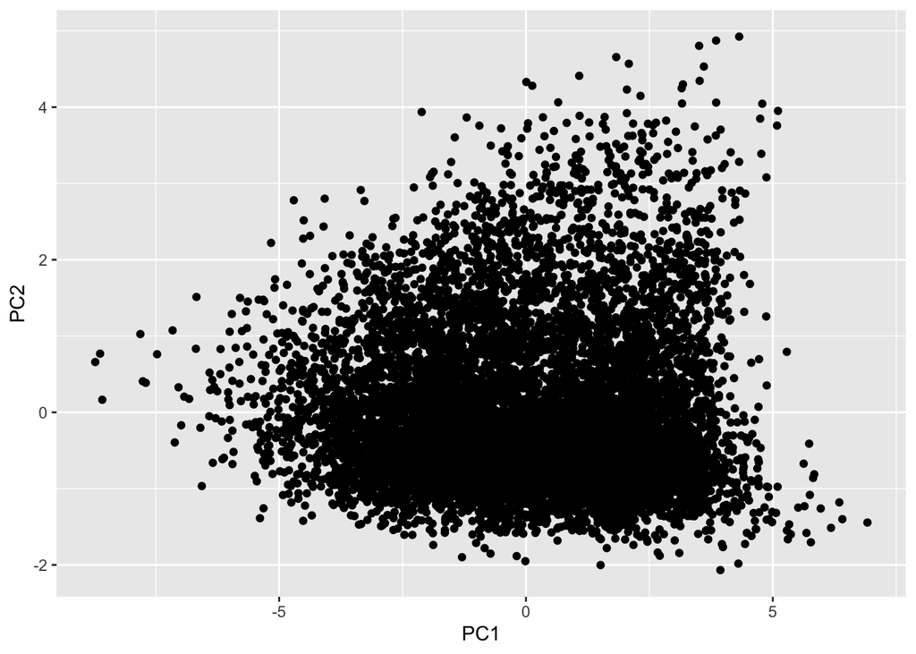

```r
# visualize
datadf <- data.frame(Name = data$Name, PC1 = data_pca$scores[,
    1], PC2 = data_pca$scores[, 2])
ggplot(datadf, aes(PC1, PC2)) + geom_point()
```

I first prepared data by selecting the Age, BodyweightKg, Best3SquatKg, Best3BenchKg, Best3DeadliftKg, TotalKg, and Wilks variables and scaling them. I ran the PCA using the princomp function. PC1 is a weakness axis. It has negative loadings for bodyweight and strength variables such as bench press strength and Wilks score. Scoring high on PC1 indicates low values for bodyweight, squat/bench/deadlift performance, total, and Wilks score. Scoring low on PC1 indicates high values for bodyweight, squat/bench/deadlift performance, total, and Wilks score. PC2 is an experience axis. It has a high positive loading for age, a lower positive loading for bodyweight, and a negative loading for Wilks score. Scoring high on PC2 indicates high values for age and bodyweight and a low Wilks score. Scoring low on PC2 indicates low values for age and bodyweight and a high Wilks score. Although powerlifters do increase their Wilks scores over the course of their careers, it makes sense that they tend to gain bodyweight and lose strength after their peak performance. Two principal components were retained because they explained 85% of the cumulative variance. Unfortunately, the plot looks like a huge blob overall. However, there are some interesting trends at the extremes. The datapoints scoring the highest on PC2 tend to also score high on PC1. This indicates that older powerlifters tend to be weaker. Also, the datapoints scoring lowest on PC2 tend to also score high on PC1. This indicates that younger powerlifters tend to be weaker. These results make sense since powerlifters tend to reach peak performance at some midpoint in their careers. This fact is also reflected in the datapoints scoring the lowest on PC1, which seem to group in a narrow range of PC2 values. This indicates that the strongest lifters tend to have a similar amount of experience.

### Linear Classifier

```r
# preparing data
data_fit = data %>%
    select(Sex, Age, BodyweightKg, Best3SquatKg, Best3BenchKg,
        Best3DeadliftKg, TotalKg, Wilks)

# logistic regression
fit = glm(Sex ~ ., data = data_fit, family = "binomial")
score = predict(fit, type = "response")

# in-sample performance
class_diag(score, truth = data$Sex, positive = 1)
```

```
##            acc   sens  spec    ppv    f1     ba    auc
## Metrics 0.9974 0.9971 0.998 0.9989 0.998 0.9975 0.9995
```

```r
# confusion matrix
table(Sex = data_fit$Sex, predictions = score > 0.5)
```

```
##    predictions
## Sex FALSE TRUE
##   0  3461    7
##   1    19 6513
```

```r
# cross-validation with logistic regression
set.seed(123)
k = 10
data1 <- data_fit[sample(nrow(data_fit)), ]
folds <- cut(seq(1:nrow(data_fit)), breaks = k, labels = F)

diags <- NULL
for (i in 1:k) {
    ## Create training and test sets
    train <- data1[folds != i, ]
    test <- data1[folds == i, ]
    truth <- test$Sex  ## Truth labels for fold i
    ## Train model on training set (all but fold i)
    fit <- glm(Sex ~ ., data = train, family = "binomial")
    ## Test model on test set (fold i)
    probs <- predict(fit, newdata = test, type = "response")
    ## Get diagnostics for fold i
    diags <- rbind(diags, class_diag(probs, truth, positive = 1))
}
diags %>%
    summarize_all(mean)
```

```
##      acc    sens    spec     ppv    f1      ba     auc
## 1 0.9974 0.99708 0.99801 0.99891 0.998 0.99755 0.99945
```

I decided to predict the binary variable Sex using the numeric variables Age, BodyweightKg, Best3SquatKg, Best3BenchKg, Best3DeadliftKg, TotalKg, and Wilks. I used logistic regression. In-sample performance was very high on all metrics. Notably, it had an accuracy of 0.9974, sensitivity of 0.9971, and AUC of 0.9995. I computed 10-fold cross validation to test its out-sample performance. The accuracy was not changed. The sensitivity decreased to 0.99708 and the AUC decreased to 0.99945. These are tiny differences so there are no signs of overfitting.

### Non-Parametric Classifier

```r
library(caret)

# knn model
knn_fit <- knn3(factor(Sex == 1, levels = c("TRUE", "FALSE")) ~
    ., data = data_fit, k = 5)
y_hat_knn <- predict(knn_fit, data_fit)

# in-sample performance
class_diag(y_hat_knn[, 1], data_fit$Sex, positive = 1)
```

```
##            acc   sens   spec    ppv     f1     ba auc
## Metrics 0.9955 0.9945 0.9974 0.9986 0.9965 0.9959   1
```

```r
# confusion matrix
table(Sex = data_fit$Sex, predictions = y_hat_knn[, 1] > 0.5)
```

```
##    predictions
## Sex FALSE TRUE
##   0  3459    9
##   1    36 6496
```

```r
set.seed(123)
k = 10
data1 <- data_fit[sample(nrow(data_fit)), ]
folds <- cut(seq(1:nrow(data_fit)), breaks = k, labels = F)

diags <- NULL
for (i in 1:k) {
    ## Create training and test sets
    train <- data1[folds != i, ]
    test <- data1[folds == i, ]
    truth <- test$Sex  ## Truth labels for fold i
    ## Train model on training set (all but fold i)
    fit <- knn3(Sex ~ ., data = train)
    ## Test model on test set (fold i)
    probs <- predict(fit, newdata = test)[, 2]
    ## Get diagnostics for fold i
    diags <- rbind(diags, class_diag(probs, truth, positive = 1))
}
diags %>%
    summarize_all(mean)
```

```
##      acc    sens    spec     ppv      f1      ba     auc
## 1 0.9935 0.99217 0.99601 0.99784 0.99499 0.99411 0.99863
```

I used the same dataset, data_fit, as for the linear classifier. The binary variable Sex was predicted using the numeric variables Age, BodyweightKg, Best3SquatKg, Best3BenchKg, Best3DeadliftKg, TotalKg, and Wilks. I used a k-nearest-neighbors with k = 5. The value of k was chosen arbitrarily. It returned a perfect AUC of 1. It also had a very large accuracy and sensitivity of 0.9955 and 0.9945, respectively. I computed 10-fold cross-validation using k-nearest-neighbors. The AUC decreased from 1 to 0.99863. The accuracy and sensitivity decreased to 0.9935 and 0.99217, respectively. Similarly to linear cross-validation, there was a very marginal decrease. However, the linear model had better cross-validation performance than the non-parametric model. The former had a difference in AUC of 10^-5 and the latter had a difference in AUC of 10^-3. There were no signs of overfitting.

### Regression/Numeric Prediction

```r
# fit linear regression
fit <- lm(Best3DeadliftKg ~ Best3BenchKg + Best3SquatKg + BodyweightKg,
    data = data_fit)
yhat <- predict(fit)
# calculate MSE
mean((data_fit$Best3DeadliftKg - yhat)^2)
```

```
## [1] 447.9492
```

```r
set.seed(123)
k = 10
data1 <- data_fit[sample(nrow(data_fit)), ]
folds <- cut(seq(1:nrow(data_fit)), breaks = k, labels = F)

diags <- NULL
for (i in 1:k) {
    ## Create training and test sets
    train <- data1[folds != i, ]
    test <- data1[folds == i, ]

    ## Train model on training set (all but fold i)
    fit <- lm(Best3DeadliftKg ~ Best3BenchKg + Best3SquatKg +
        BodyweightKg, data = train)
    ## Test model on test set (fold i)
    yhat <- predict(fit, newdata = test)
    ## Get diagnostics for fold i
    diags <- mean((test$Best3DeadliftKg - yhat)^2)
}
# average MSE
mean(diags)
```

```
## [1] 424.5941
```

### Python

```r
library(reticulate)
data %>%
    arrange(-TotalKg) %>%
    head -> strongest_lifters
strongest_lifters = strongest_lifters$Name
```

```python
print(r.strongest_lifters)
```

```
## ['Don Reinhoudt', 'Kelly Branton', 'Josh Morris #1', 'Robb Philippus', 'Jezza Uepa', 'Ivan Podrez']
```

```python
type(r.strongest_lifters)
```

```
## <class 'list'>
```

I used dplyr to arrange the dataframe from strongest lifters to weakest lifters, using TotalKg as the metric for strength. I used the head function to retain the six strongest observations. I extracted the Name column and saved it as the strongest_lifters variable. I then printed it using python and checked the type of the object to verify it was a list. I primarily wanted to mess around with converting a column from a tidy dataframe in R to a list in python.

### Concluding Remarks

As a lifter, I found the results very interesting because they often reflected personal observations. For example, I touched on the Longhorn powerlifting observation in the clustering section. I will have to do more research to find an explanation. Also, I have observed that female lifters tend to have weaker bench presses relative to their squats and deadlifts than male lifters do. I believe that this metric is what allowed for such high AUCs in the linear and non-parametric classification and cross-validation. In the future, I would like to rerun this section without including Best3BenchKg. There were some unexpected results, however. Primarily, I was surprised by how PC1 and PC2 were defined. They made sense in hindsight, but I would have never expected experience to be such an important factor in explaining variation in powerlifters. Lastly, I was surprised by the large MSE when predicting deadlift performance from bench press and squat performance and bodyweight. This may suggest that there are more important variables that determine deadlift performance. I theorize that one of these is the anthropometry of the individual, which would be difficult to measure.